# Project_1_wordcloud

WendyD

9/21/2020

```
## [1] "/Users/anhthudoan/Columbia/GR5243/Fall2020-Project1-salmonkween"
```

# Introduction

The data I used for this report comes from American National Election Studies(ANES). The original data has 1029 variables. To make thing easier, I subseted the data by variables of interest, and saved it as data1

# What make a person choose one party over the other?

Since the day I came to the US, I have always been intrigued about the US democracy system. Coming from a Communist country, where the Vietnam Communist Party is the sole governing political party, I found the rivalry between the Democratic and Republican parties very interesting. With so many options, I have always wondering: What make a person choose one party over another?

I looked into their answers to the questions: what do voters like/don’t like about the party? I analyzed their answers, and made a word cloud plots based on the frequency that key words popped up. The plots gave some interesting insights on the each party’s characteristics.

# Republican vs Democratics: which party has a “smarter” voting base?

Graduated from a liberal art college in dominantly blue state, Minnesota, I have always believe that people who support Democratics are smarter, more educated, hence the liberal points of views, in comparison to Republican supporters. At least, that is what my American classmates told me. I wonder if that is true.

To answer this question, I take a look at the education distribution of the voters versus political identification. I started with 2016, which to many people, had the most unexpected election outcomes.

```r
data1 <- read.csv("output/anes_edu.csv", header=TRUE)
```

```
##             Grade School High School Some Colleges College or higher
## Democratics    1.3513514     23.7526      32.74428          42.15177
## Republican     0.6980803     22.2804      37.28912          39.73240
```

It seems like so far in 2016, people who have college degrees and higher tend to identify themselves as democrat, though the ratio is not much higher.

Let us look at the data across the year, to see if this phenomenon still apply over time

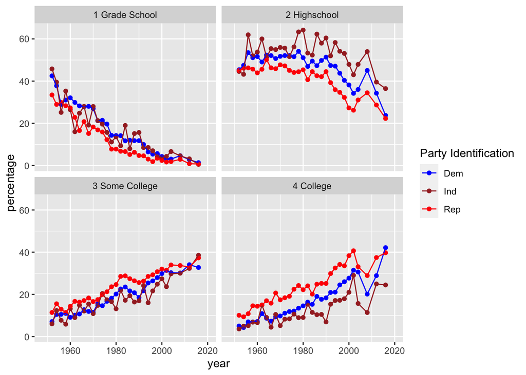

Across the years, there has been a decline in voters without a college degree. College-educated voters, on the other hand, have increased, according to the analysis. There have been more and more people went to get higher degrees, thus introducing an upward trends in some college and colleges education groups on the graph.

This realization came to me as a total surprise. To render my analysis more quantitative, I look at percentage difference between the Democrats and Republicans for each of the educational groups

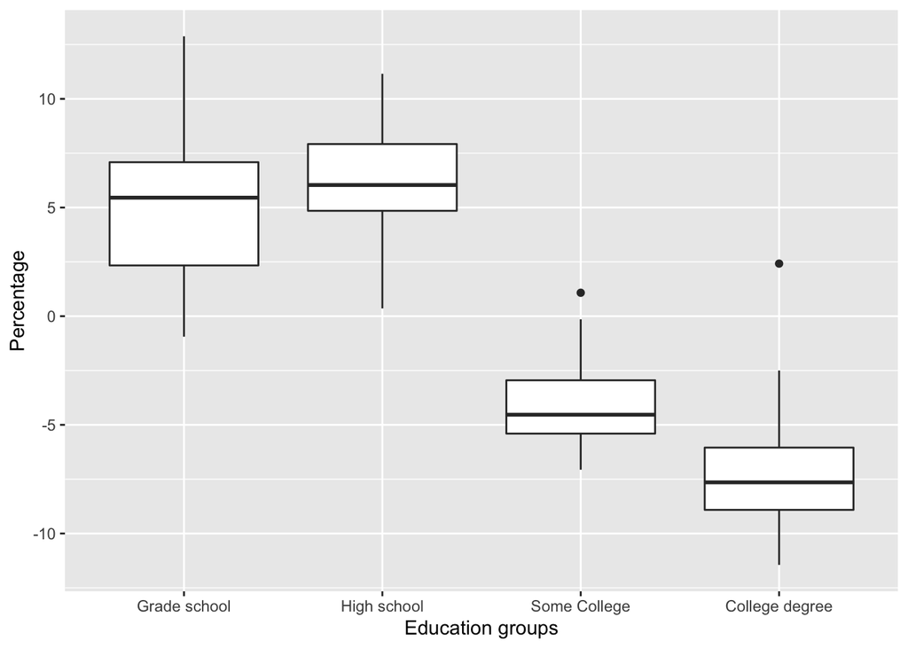

This boxplot indicates two things:

- People with high school degree or lower tend to vote for democrats more. On the other hands, Republicans have a stronger base in higher educational groups (college degree or higher).
- 2016 is an outlier for the `college and higher` category, while 2012 is an outlier for the `some colleges` category. This means that there was a shift in political preference among the higher educational groups in 2016, as more people with college degree vote for democrats more than for republicans.

## Keywords about each party

I tried to reason the political preference for each different educational background by looking at voter answers to the questions: what do voters like/don’t like about the party? I analyzed their answers, and made a word cloud plots based on the frequency that key words popped up. The plots gave some interesting insights on the each party’s characteristics.

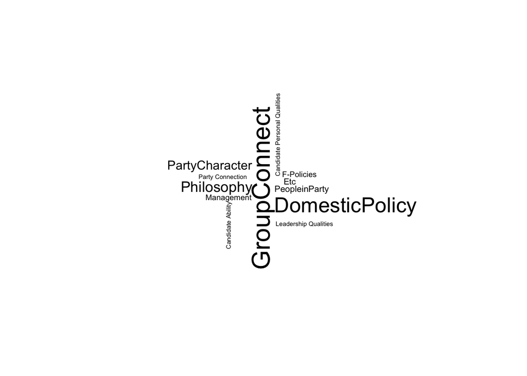

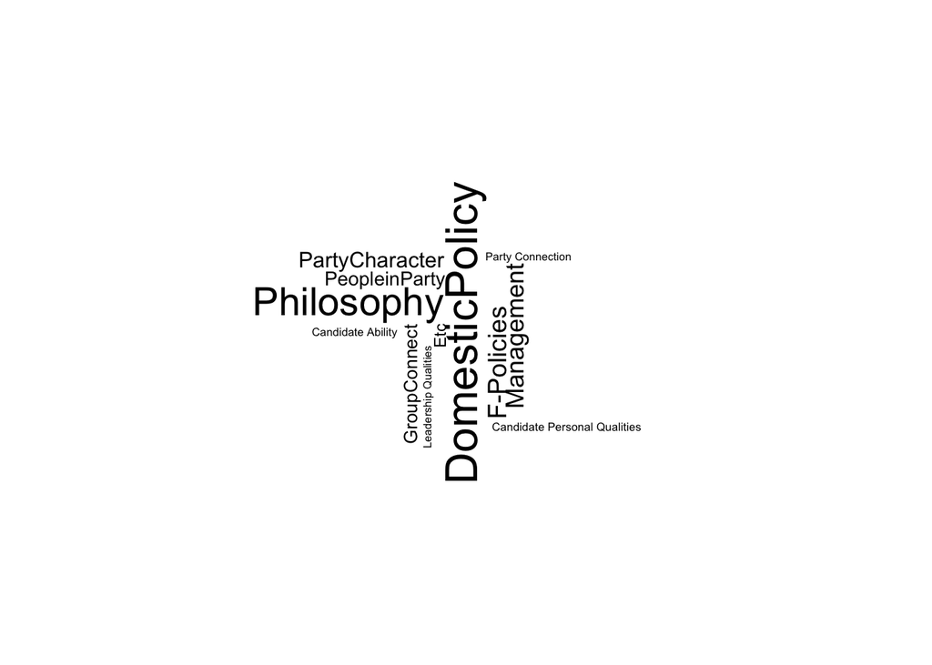

Democratic party win voters favor with their Group Connection quality, and their Domestic Policies. Voters, on the other hand, resonance with Republican Party on their Domestic Policy, Philosophy, Management skills.

We repeat the same process to answer the question: what characteristics in each parties that make voters hate:

```
## [1] 17601     1
```

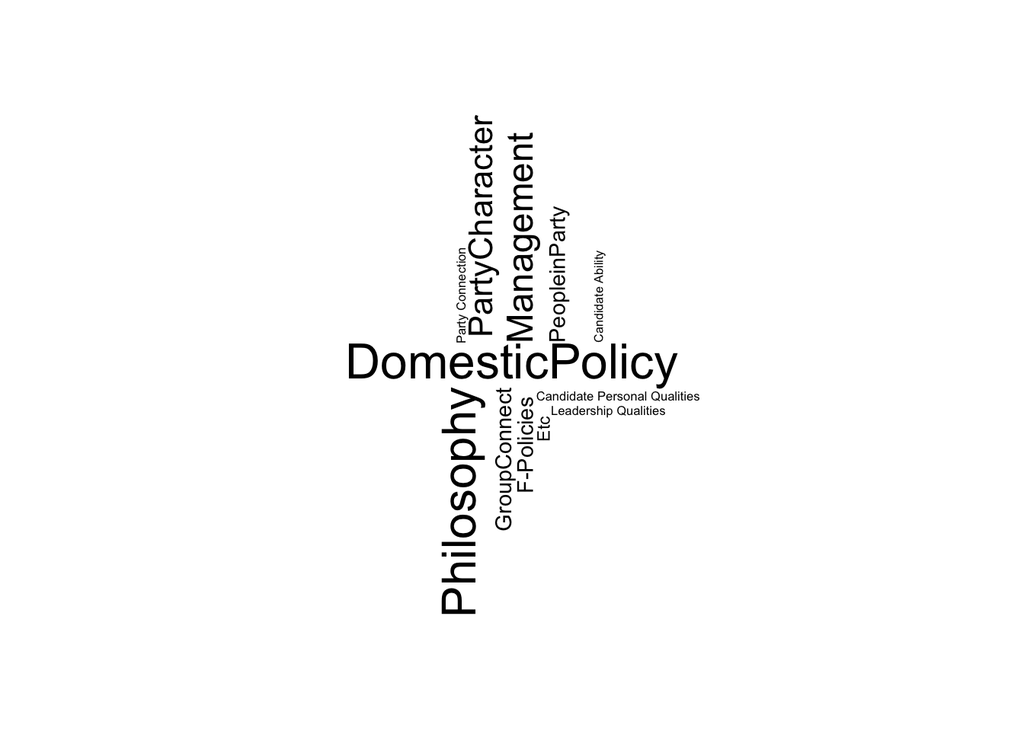

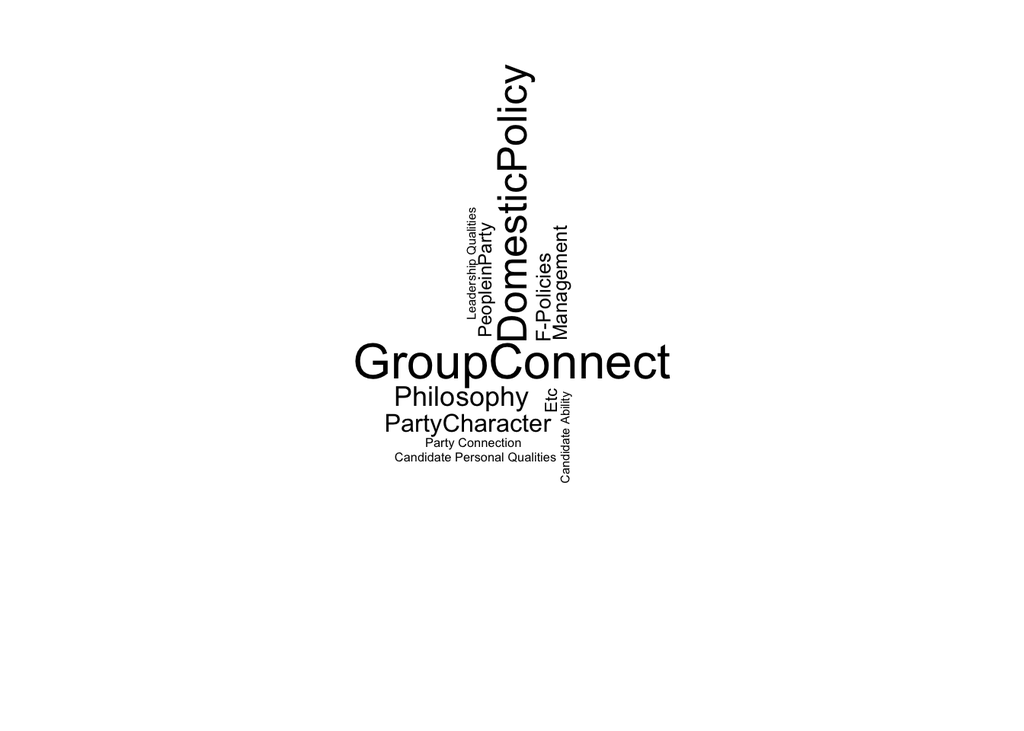

Connecting this to our previous finding, that higher educated voters prefer republicans, the word cloud plots make total sense. People who have lower income tend to come from a less educated background. These people choose Democrats because the party offer a superior group connection quality, with a promise of equal pay, higher tax for the reach, and most importantly, inclusivity for the poor. The voters who have higher education, enjoyed a higher pay positions, want to maintain their social status, so they resonance more with the Republican’s conservative philosophy. These voters place an emphasis on the party’s management skill in preserving the rich’s benefits.